# Lending Club Analysis - Capstone Project

Mike Halpert

5/21/2017

## Lending Club Loan Default Analysis

Lending Club is a crowd lending service enabling individual investors to offer micro-loans to borrowers. Lending Club maintains a rich history of loan information on all of its borrowers. The purpose of this analysis is to see if it is possible to build predictive models that could help investors better understand the risks of default, and avoid risky borrowers in their lending criteria.

## About Lending Club

[Lending Club](https://www.lendingclub.com/public/how-peer-lending-works.action) is a crowd lending platform that enables pools of individual investors to act in the capacity of a bank and make loans to individual borrowers.The Lending Club process is straightforward. A borrower applies for a loan, and then Lending Club posts the application on their platform for individual investors to fund in $25 increments. These micro-loan obligations are called “notes”. Once the borrower’s loan is funded, they are required to make monthly payments of principal and interest on the notes for either a 36 or 60 momth term. Lending club assigns each loan a letter grade and interest rate based on the borrower’s credit-worthiness. The lower risk loans such as “A’s” and “B’s” are much safer, but return a much lower interest rate to lenders, around 3%-4%. Loans with grading’s such as “E”, “F”, and “G” are much riskier, but can yield returns of over 25%.

## Project Purpose

Many lending club loans are risky and have default potential. The goal of this project is to understand how to identify risky borrowers, while maximizing yield for the investor. As an individual investor, Lending Club offers the potential for returns that exceed traditional investments such as bonds, index ETF’s or even individual stocks. However, the risk of default is quite real. Similar to credit cards or other uncollateralized loans, many borrowers miss payments, default or go bankrupt creating a total loss of principal for the investor. The goal of this project is to develop an investing methodology for picking the best high yielding notes that offer the lowest probability of default and principal loss.

## Data Sources

Luckily, Lending Club is a very data intense platform and they provide very thorough statistics and structured data on their entire history of loan performance. Their loan data goes back all the way through 2007.

Loan Files:  
- [Loan Data Files](https://www.lendingclub.com/info/download-data.action)  
- [Data Dictionary](https://resources.lendingclub.com/LCDataDictionary.xlsx)

The Loan Data Files include:

- Borrower demographics, employment and income status
- Credit Histories & Credit Scores
- Information on existing credit accounts, limits, loan status’, and delinquencies
- Loan amounts and purposes
- Lending Club repayment histories and late fees

## Approach

The loan data files have incredibly rich information on repayments and defaults spanning back through 2007. As loans can only be borrowed in 36 and 60 month terms, many of the loans from the early year vintages have already reached full maturity. This provides a very rich training set to create a machine learning model that will predict the probability of default or full repyament based on existing history.

I will start my exploration with a statistical analysis of loan defaults. I will seek out high correlations between various loan attributes and outcomes.

My initiail hypothesis for why borrowers default on notes include:

- High debt to income ratios
- Decreases in applicant credit scores
- Frivoulous loan purposes, or loans not tied to refinancing/consolidation
- Debt consolidation loans that exceed initial debt levels
- A history of previous loan delinquiencies

This analysis will help inform the approach on developing a machine learning model that will predict the probability of loan repayment to full maturuty. We can test the validity of this model by rewinding the tape 2 years with a sample data set to see how it would perform with recent historic data. By feeding the model loan application information from 2014-2016, we can see what predictions the model would make on various loans. Since we know how this sample of future data will perform, we can test the validity of the machine learning model.

## Cleaning the Data

While the Lending Club data is detailed, it is slightly messy and requires quite a bit of cleaning. There are a number of issues with the data set including:

- There are a number of loans that have not matured. We are only interested in early vintage loans that have either been fully repaid or defaulted.
- Many of the fields feature text which R interprets as a string instead of a numeric or factor.
- Many of the fields are highly similar or duplicates of other fields.
- There are a number of columns that are full of NA’s which have been added for later vinatge loans. These fields are unneeded for this analysis.
- The data set features a number of empty columns, NA’s and other columns where a null result is a 0. These need to be normalized.
- There are a number of features where the factors have too many levels. In many of the outputs, our need is to find a binary yes/no output.
- The Data Set also features extranious loan outcome fields that are heavily correlated to the loan outcome. We are only interested in working with data features that we would have when a new loan is published. It would be impossible to have certain elements such as a borrowers credit score 3 years in the future when deciding to fund a loan, so we need to remove these from the data set.

```r
RawLoanData <- read.csv("LoanStats3a_securev1.csv", skip = "1", sep = ",", header = TRUE)

dropcolumnindex <- lapply(RawLoanData, function(x) sum(is.na(x))) >= 42300
RawLoanData <- RawLoanData[ , dropcolumnindex == FALSE]


#Fixing NA's in records where 0's should be present.
RawLoanData$int_rate <- as.numeric(gsub("\\%", "", RawLoanData$int_rate))*.01
RawLoanData$revol_util <- as.numeric(gsub("\\%", "", RawLoanData$revol_util))*.01
RawLoanData$dti <- RawLoanData$dti * 0.01
RawLoanData$delinq_2yrs[is.na(RawLoanData$delinq_2yrs)] <- 0
RawLoanData$inq_last_6mths[is.na(RawLoanData$inq_last_6mths)] <- 0
RawLoanData$open_acc[is.na(RawLoanData$open_acc)] <- 0
RawLoanData$pub_rec[is.na(RawLoanData$pub_rec)] <- 0
RawLoanData$total_acc[is.na(RawLoanData$total_acc)] <- 0
RawLoanData$acc_now_delinq[is.na(RawLoanData$acc_now_delinq)] <- 0
RawLoanData$mths_since_last_delinq[is.na(RawLoanData$mths_since_last_delinq)] <- 0
RawLoanData$open_acc[is.na(RawLoanData$open_acc)] <- 0
RawLoanData$mths_since_last_record[is.na(RawLoanData$mths_since_last_record)] <- 0
RawLoanData$revol_util[is.na(RawLoanData$revol_util)] <- 0
RawLoanData$pub_rec_bankruptcies[is.na(RawLoanData$pub_rec_bankruptcies)] <- 0


## Removing outcome fields that distor the machine learning models.
RawLoanData$recoveries <- NA
RawLoanData$collection_recovery_fee <- NA
RawLoanData$total_pymnt <- NA
RawLoanData$total_rec_prncp <- NA
RawLoanData$total_rec_int <- NA
RawLoanData$total_rec_late_fee<- NA
RawLoanData$last_pymnt_amnt <- NA
RawLoanData$last_fico_range_high <- NA
RawLoanData$pymnt_plan <- NA
RawLoanData$acc_now_delinq <- NA
RawLoanData$delinq_amnt <- NA


#Removing text heavy & extranious fields that will likely not impact the moddels.
RawLoanData$url <- NA
RawLoanData$desc <- NA
RawLoanData$emp_title <- NA
RawLoanData$title <- NA
RawLoanData$application_type <- NA
RawLoanData$initial_list_status <- NA
RawLoanData$grade <- NA
RawLoanData$last_pymnt_d <- NA
RawLoanData$last_credit_pull_d <- NA
RawLoanData$earliest_cr_line <- NA
RawLoanData$zip_code <- NA
RawLoanData$issue_d <- NA
RawLoanData$addr_state <- NA
RawLoanData$next_pymnt_d <- NA
RawLoanData$id <- NA
RawLoanData$member_id <- NA
RawLoanData$funded_amnt_inv <- NA
RawLoanData$funded_amnt <- NA
RawLoanData$policy_code <- NA
RawLoanData$fico_range_low <- NA
RawLoanData$last_fico_range_low <- NA
RawLoanData$out_prncp <-NA
RawLoanData$out_prncp_inv <- NA
RawLoanData$total_pymnt_inv <- NA
RawLoanData$chargeoff_within_12_mths <- NA
RawLoanData$collections_12_mths_ex_med <- NA
RawLoanData$tax_liens <- NA


## Cleaning up factored fields

#Fixing Factors
RawLoanData$term <- droplevels(RawLoanData$term)
RawLoanData$sub_grade <- droplevels(RawLoanData$sub_grade)
RawLoanData$emp_length <- droplevels(RawLoanData$emp_length)
RawLoanData$verification_status <- droplevels(RawLoanData$verification_status)
RawLoanData$purpose <- droplevels(RawLoanData$purpose)

#Fixing Home ownership field levels

RawLoanData$home_ownership[which(RawLoanData$home_ownership == "NONE")] <- NA
RawLoanData$home_ownership[which(RawLoanData$home_ownership == "")] <- NA
na_index4 <- which(is.na(RawLoanData$home_ownership))
RawLoanData <- RawLoanData[-na_index4, ]
RawLoanData$home_ownership <- droplevels(RawLoanData$home_ownership)


## Removing current loans as they are out of analysis range.
RawLoanData$loan_status[which(RawLoanData$loan_status == "Current")] <- NA
RawLoanData$loan_status[which(RawLoanData$loan_status == "")] <- NA
RawLoanData$loan_status[which(RawLoanData$loan_status == "Late (16-30 days)")] <- NA
RawLoanData$loan_status[which(RawLoanData$loan_status == "Late (31-120 days)")] <- NA
RawLoanData$loan_status[which(RawLoanData$loan_status == "In Grace Period")] <- NA
na_index3 <- which(is.na(RawLoanData$loan_status))
RawLoanData <- RawLoanData[-na_index3, ]


# Consolidating defaulted loans.  0 will signify paid back loan.  1 will equal default.
RawLoanData$loan_status <- as.factor(gsub("Does not meet the credit policy. Status:Fully Paid", "0", RawLoanData$loan_status))
RawLoanData$loan_status <- as.factor(gsub("Does not meet the credit policy. Status:Charged Off", "1", RawLoanData$loan_status))
RawLoanData$loan_status <- as.factor(gsub("Fully Paid", "0", RawLoanData$loan_status))
RawLoanData$loan_status <- as.factor(gsub("Charged Off", "1", RawLoanData$loan_status))
RawLoanData$loan_status <- as.factor(gsub("Default", "1", RawLoanData$loan_status))

#Dopping final empty variable columns.  This removes extranious loans from the analysis where we do not have enough input information.
dropcolumnindex <- lapply(RawLoanData, function(x) sum(is.na(x))) >= 42300
RawLoanData <- RawLoanData[ , dropcolumnindex == FALSE]
```

## Additional Feature Creation

One of the most interesting elements in a loan is understanding debt burden on a borrower. Can they afford to make loan repayments while paying for everyday items such as housing, food, transportation, etc.. In order to add this feature to our analysis, we are creating a new variable called dti_lc which shows the percentage of monthly income that a lending club installment payment takes up of thier income.

```r
RawLoanData$dti_lc <- RawLoanData$installment / (RawLoanData$annual_inc/12)
```

## Important Variables

| Variable | Definition |
| --- | --- |
| Term | Length of the loan. Either 36 or 60 Months |
| int_rate | Rate of interest charged on loan |
| installment | Monthly loan repayment owed by borrower. |
| sub_grade | Grade of the loan that is assigned by lending club. This is tied to the interest rate on the loan. |
| emp_lenth | How long has the borrower been employed with their current employer. |
| home_ownership | The borrowers housising is either fully owned, mortgaged, rented or they have another arrangement. |
| verification_status | Have the details of the loan, employment and income been verified by lending club. |
| purpose | What is the loan being used for? |
| dti | Debt to Income. What is the borrowrers total debt burden as reported by the credit bureau. |
| delinq_2years | How many delinquincies does the borrower have on their credit history over the last 2 years. |
| fico_range_high | The high end of the reported FICO credit score of the borrower. |
| inq_last_6mths | How many credit inquiries has the borrower had on their credit file over the last 6 months. |
| mths_since_last_delinq | How many months has it been since the last delinquency on the borrowers credit file. |
| mths_since_last_record | How many months has it been since the last record on the borrowers credit file. |
| open_acc | How many open credit accounts a borrower has on their credit file. |
| pub_rec | The number of public redords a borrower has on their credit file. |
| revol_bal | How much debt does the borrower currently posses. |
| revol_util | What is the proportion of credit utilized by the borrower. |
| total_acc | Number of credit accounts that a borrower has open on their credit file. |
| pub_rec_bankruptcies | Number of times a borrower has declared bankruptcy. |
| dti_lc | Debt burden of monthly lending club installment payments relative to a borrowers income. |
| loan_status | Was the loan repaid, or did the borrower default. |

## Initial Data Inspection

Our data set contains 42512 observations. This should be more than sufficient to attempt working with various predictive models. Our defaults will be labeled as 1, and our repaid loans will be labeled as 0.

### Rate of Default

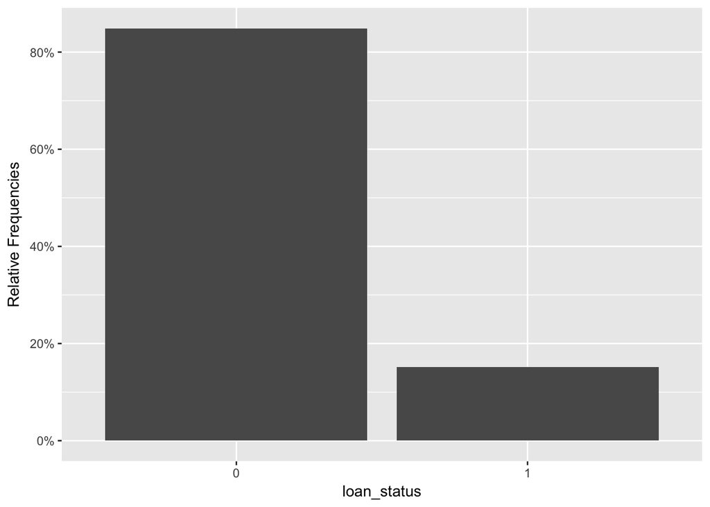

We can see that 84.9% of the loans are repaid, and 15.1% of the loans default.

### Rate of Default by Loan Grade

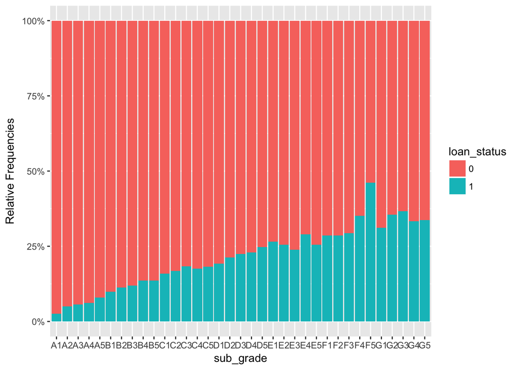

More interestingly we can see that the rate of default goes up substantially with the grade of the loan. The A1 loans rarely default, but the G rated loans default almost 1/3 of the time.

### Rate of default by Income

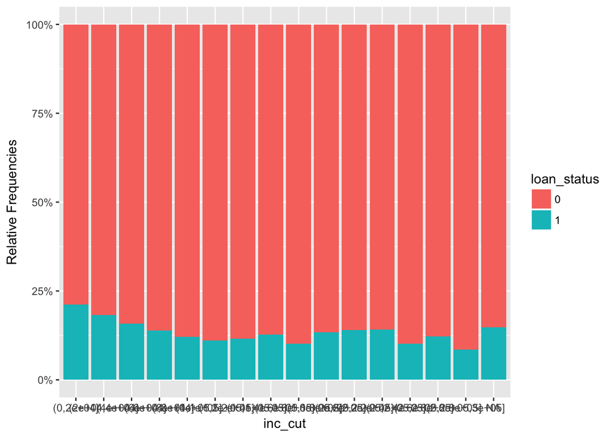

Income does not seem to have a substantial impact on the rate of default. The rate decreases as incomes approach $40K per year. Then however it seems to increase again

### Rate of default by DTI

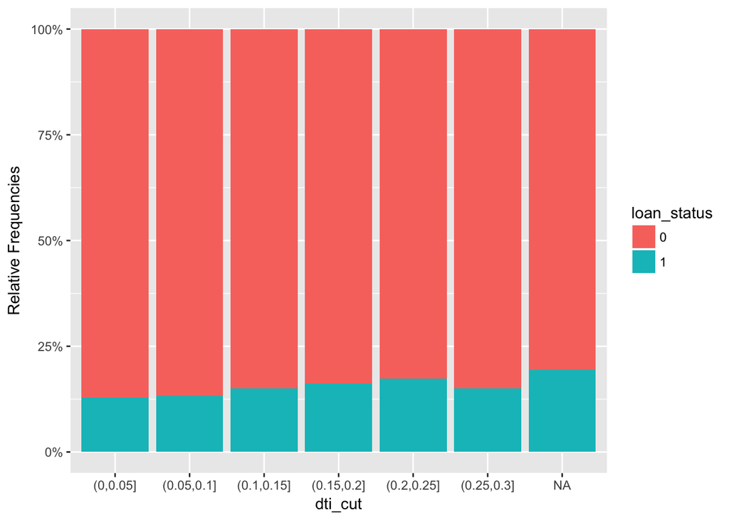

The rate of default does not seem to be highly impacted by Debt-to-Income as reported by the credit beureaus. The variance seems quite small, although steadily increasing as people carry more debt. This does not seem entirely logical. It is likely more important to asses thier debt levels after a loan is received.

### Rate of default by DTI post funding (DTI_LC)

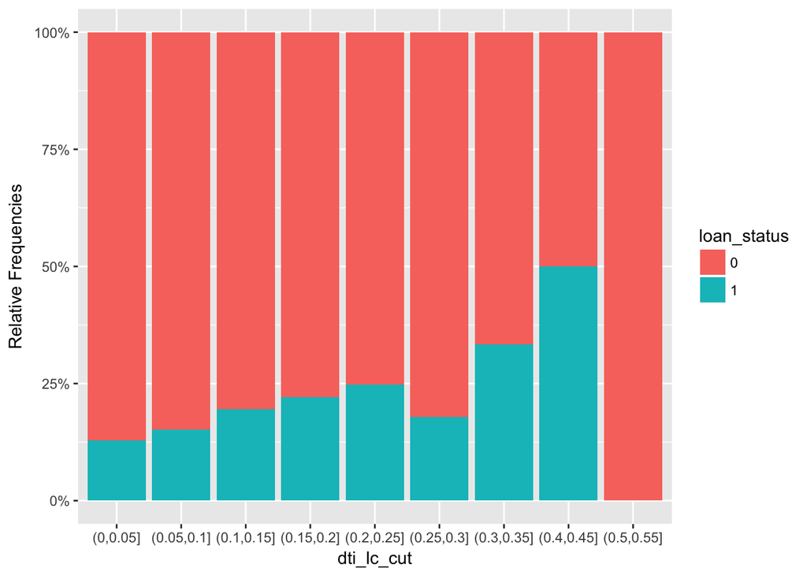

### Rate of default by Credit Score

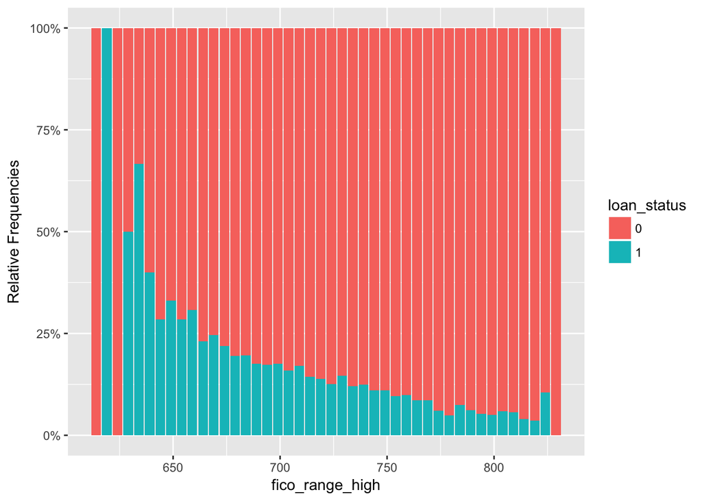

It appears that defaults are highly influenced by FICO credit scores. Lower scores seems to have a much higher likelehood of default. It appears that investing in loans below a score of 640 is highly risky.

### Rate of default by Previous Deliquincy

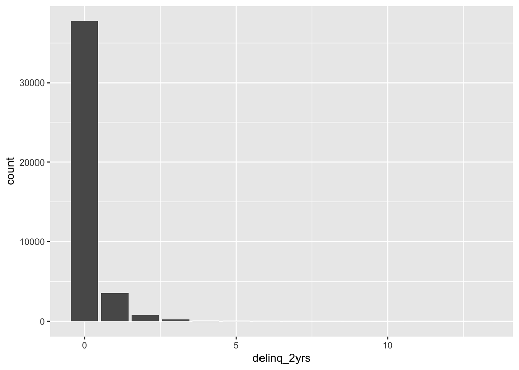

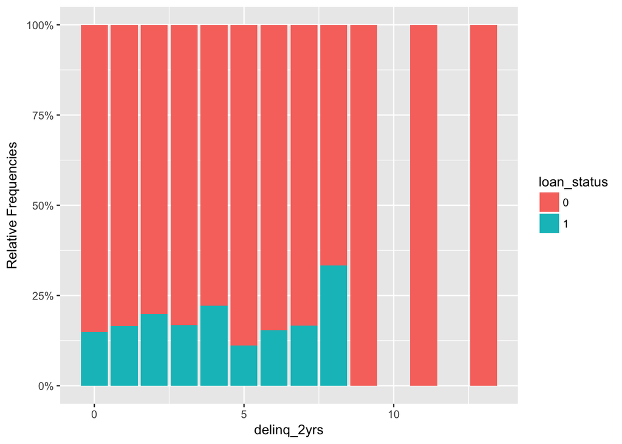

## Initial Data Review

The data seems to imply that Lending Club is performing its own basic credit underwriting analysis on borrowers at the time they apply for a loan. It seems that they are using all the of the borrower info such as income, credit scores, home ownership, credit history, etc. to assign them to a loan. As such it seems straightforward that A rated loans are less risky than G rated loans. Likely that A rated loans are not offered to a large subset of borrowers.

What is most interesting is that post-loan debt burden seems to be the largest indicator of loan default. It is not so much that it is neccesarily tied to a specific level of income, as it is tied to a borrowers total monthly expesnses. It appears to have even more significance than previous delinquiencies.

Based on this information, this analysis is going to construct 3 different predictive models to predict loan repayment or default. It will utilize logistic regression, categorization trees and random forest models. Based on the information above, it seems that categorization treees might work most effectively as there seem to be some pretty straightforward conditions related to a borrowers debt burden. The optimal model should help create a tool that enables a lender to decide wether or not to invest into a loan.

There are also a few questions that this analysis will unfortunately not be able to answer. First and foremost, there is limtied information about why people default. We know some of their financial conditions up front, but there are no realtime indicators of default other than monthly non-payment. It does not say because it is due to loss of a job or increased expenses, etc.. Unfortunately, this means that this data will not provide us with advance warning signs that would help enable us to trade loans already in our portfolio that are more likely to default in the near future.